# Introduction to Statistical Analysis

## Chi-square test

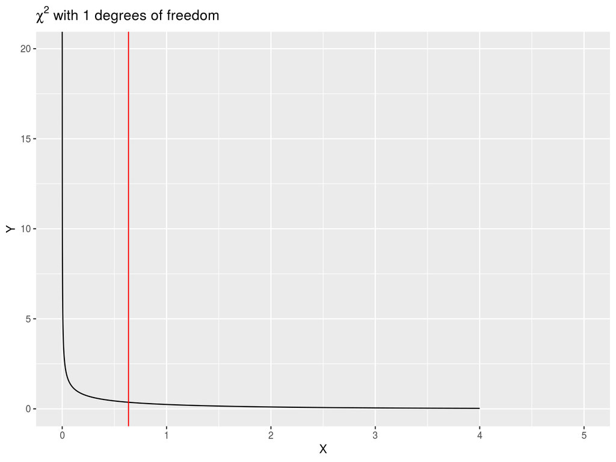

*Do not reject $H_0$ (No evidence of an association between treatment group and tumour shrinkage)*

## Limitations of the chi-square test

- In general, a Chi-square test is appropriate when:
  - at least 80% of the cells have an expected frequency of 5 or greater
  - none of the cells have an expected frequency less than 1
- If these conditions aren’t met, *Fisher’s exact test* should be used.

## Same question, smaller sample size

- e.g. Research question: Is there an association between treatment group and tumour shrinkage?

- Null hypothesis: $H_0$: No association
- Alternative hypothesis: $H_1$: Some association

## Fishers’ exact test; results

Expected frequencies:-

|  | Tumour.Did.Not.Shrink | Tumour.Did.Shrink |
| --- | --- | --- |
| Treatment | 7.8 | 3.2 |
| Placebo | 9.2 | 3.8 |

- Test statistic: N/A
- P-value 1
- Interpretation: ***Do not reject** $H_0$ (No evidence of an association between treatment group and tumour shrinkage)

## Chi-square test for trend

- e.g. Research question: Is there a linear association between tumour grade and the incidence of tumour shrinkage

- Null hypothesis: $H_0$: No linear association
- Alternative hypothesis: $H_1$: Some linear association

## Expected frequencies

[output not shown]

Expected

```
        Tumour.Did.Not.Shrink Tumour.Did.Shrink
Grade 1                  12.0              11.0
Grade 2                  15.2              13.8
Grade 3                  16.8              15.2
```

## Chi-square test for trend

## Chi-square test for trend; results

Test statistic: 10.18 DF = 1 P-value = 0.001 *Reject* $H_0$ (evidence of a linear association between tumour grade and tumour shrinkage)

## Summary - Categorical variables

- Chi-square test
  - Use when we have two categorical variables, each with two or more levels, and our expected frequencies are not too small.
- Fishers exact test
  - Use when we have two categorical variables, each with two levels, and our expected frequencies are small.
- Chi-square test for trend
  - Use when we have two categorical variables, where one or both are naturally ordered and the ordered variable has at least three levels, and our expected frequencies are not too small.
- (McNemar’s test)
  - Use when we have two categorical paired variables.

## Summary - Categorical variables

- Turn scientific question to null and alternative hypothesis
- Calculate expected frequencies
- Think about test assumptions
- Carry out chi-square or Fishers test if appropriate

## Contingency table practical

- Complete contingency table practical